# Machine Learning Assignment

#### *author:* Sonat

#### *date:* 14 Oct 2015

#### *output:* html_document

### Background

Using devices such as Jawbone Up, Nike FuelBand, and Fitbit it is now possible to collect a large amount of data about personal activity relatively inexpensively. These type of devices are part of the quantified self movement - a group of enthusiasts who take measurements about themselves regularly to improve their health, to find patterns in their behavior, or because they are tech geeks. One thing that people regularly do is quantify how much of a particular activity they do, but they rarely quantify how well they do it. In this project, your goal will be to use data from accelerometers on the belt, forearm, arm, and dumbell of 6 participants. They were asked to perform barbell lifts correctly and incorrectly in 5 different ways. More information is available from the website here: http://groupware.les.inf.puc-rio.br/har (see the section on the Weight Lifting Exercise Dataset).

### Data

The training data for this project are available here:

https://d396qusza40orc.cloudfront.net/predmachlearn/pml-training.csv

The test data are available here:

https://d396qusza40orc.cloudfront.net/predmachlearn/pml-testing.csv

### Objective

The goal of your project is to predict the manner in which they did the exercise. This is the “classe” variable in the training set.

### Loading and Cleaning Data

First we load the necessary libraries, plant seed for reproduceability and load data.

pmlTrain <- read.csv(url(“https://d396qusza40orc.cloudfront.net/predmachlearn/pml-training.csv”),stringsAsFactors = FALSE)

pmlTest <- read.csv(url(“https://d396qusza40orc.cloudfront.net/predmachlearn/pml-testing.csv”),stringsAsFactors = FALSE)

```r
library(knitr)
library(caret)

set.seed(123)

pmlTrain <- read.csv(url("https://d396qusza40orc.cloudfront.net/predmachlearn/pml-training.csv"),stringsAsFactors = FALSE)
pmlTest <- read.csv(url("https://d396qusza40orc.cloudfront.net/predmachlearn/pml-testing.csv"),stringsAsFactors = FALSE)

dim(pmlTest)
```

```
## [1]  20 160
```

```r
dim(pmlTrain)
```

```
## [1] 19622   160
```

So we have 160 predictors. We need to do a bit of cleaning. We can for example remove predictors that are character, since modeling requires numeric observations.

We should remove those predictors which have some NA values in them.

```r
training_dt <- as.matrix(sapply(pmlTrain,typeof))
training_dt_char <- which(training_dt[,1] == "character")
```

However before we do that we need to exclude “classe” variable because this is what we would like to predict. The following reveals the index where this variable is.

```r
inx <- training_dt_char["classe"]
inx
```

```
## classe
##    160
```

It is 160, thus we remove this and we remove all other predictors that are of type character.

```r
training_dt_char <- setdiff(training_dt_char,inx)
pmlTrain <- pmlTrain[,-training_dt_char]
```

We should also remove predictors containg NA values.

```r
pmlTrain <- pmlTrain[,colSums(is.na(pmlTrain)) == 0]
```

X is only the id number of the observation. Thus needs to be removed.

```r
pmlTrain$X <- NULL
```

We have to predict variable “classe”, let’s convert “classe” into factor

```r
pmlTrain$classe <- as.factor(pmlTrain$classe)
```

### Analysis and Prediction

```r
inTrain <- createDataPartition(y=pmlTrain$classe,p=0.90,list=FALSE)
training <- pmlTrain[inTrain,]
testing <- pmlTrain[-inTrain,]
```

```r
dim(pmlTrain)
```

```
## [1] 19622    56
```

```r
dim(training)
```

```
## [1] 17662    56
```

```r
dim(testing)
```

```
## [1] 1960   56
```

In fact a good model would be random forest.

```r
ctrl = trainControl(method="repeatedcv", number=2, repeats=1, selectionFunction = "oneSE")
modFit <- train(classe ~., data=training, method="rf",trControl=ctrl)
modFit
```

```
## Random Forest
##
## 17662 samples
##    55 predictor
##     5 classes: 'A', 'B', 'C', 'D', 'E'
##
## No pre-processing
## Resampling: Cross-Validated (2 fold, repeated 1 times)
## Summary of sample sizes: 8830, 8832
## Resampling results across tuning parameters:
##
##   mtry  Accuracy   Kappa      Accuracy SD   Kappa SD
##    2    0.9928658  0.9909750  0.0025634137  0.0032431487
##   28    0.9984712  0.9980663  0.0005607416  0.0007093097
##   55    0.9972824  0.9965625  0.0009604165  0.0012149148
##
## Accuracy was used to select the optimal model using  the one SE rule.
## The final value used for the model was mtry = 28.
```

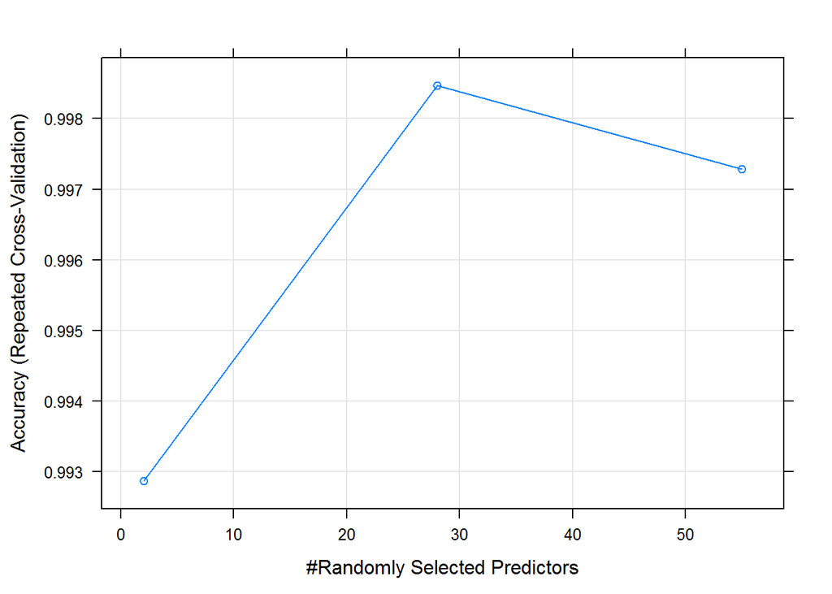

```r
plot(modFit)
```

```r
pred <- predict(modFit,testing)
confusionMatrix(pred,testing$classe)
```

```
## Confusion Matrix and Statistics
##
##           Reference
## Prediction   A   B   C   D   E
##          A 558   0   0   0   0
##          B   0 379   0   0   0
##          C   0   0 342   0   0
##          D   0   0   0 321   0
##          E   0   0   0   0 360
##
## Overall Statistics
##
##                Accuracy : 1
##                  95% CI : (0.9981, 1)
##     No Information Rate : 0.2847
##     P-Value [Acc > NIR] : < 2.2e-16
##
##                   Kappa : 1
##  Mcnemar's Test P-Value : NA
##
## Statistics by Class:
##
##                      Class: A Class: B Class: C Class: D Class: E
## Sensitivity            1.0000   1.0000   1.0000   1.0000   1.0000
## Specificity            1.0000   1.0000   1.0000   1.0000   1.0000
## Pos Pred Value         1.0000   1.0000   1.0000   1.0000   1.0000
## Neg Pred Value         1.0000   1.0000   1.0000   1.0000   1.0000
## Prevalence             0.2847   0.1934   0.1745   0.1638   0.1837
## Detection Rate         0.2847   0.1934   0.1745   0.1638   0.1837
## Detection Prevalence   0.2847   0.1934   0.1745   0.1638   0.1837
## Balanced Accuracy      1.0000   1.0000   1.0000   1.0000   1.0000
```

The following would be then the test against test data.

```r
pred2 <- predict(modFit,pmlTest)
pred2
```

```
##  [1] B A B A A E D B A A B C B A E E A B B B
## Levels: A B C D E
```